# Self-Driving Car Engineer Nanodegree

## Project: Build a Traffic Sign Recognition Classifier

In this notebook, a template is provided for you to implement your functionality in stages which is required to successfully complete this project. If additional code is required that cannot be included in the notebook, be sure that the Python code is successfully imported and included in your submission, if necessary. Sections that begin with **'Implementation'** in the header indicate where you should begin your implementation for your project. Note that some sections of implementation are optional, and will be marked with **'Optional'** in the header.

In addition to implementing code, there will be questions that you must answer which relate to the project and your implementation. Each section where you will answer a question is preceded by a **'Question'** header. Carefully read each question and provide thorough answers in the following text boxes that begin with **'Answer:'**. Your project submission will be evaluated based on your answers to each of the questions and the implementation you provide.

> **Note:** Code and Markdown cells can be executed using the **Shift + Enter** keyboard shortcut. In addition, Markdown cells can be edited by typically double-clicking the cell to enter edit mode.

## Step 1: Dataset Exploration

Visualize the German Traffic Signs Dataset. This is open ended, some suggestions include: plotting traffic signs images, plotting the count of each sign, etc. Be creative!

The pickled data is a dictionary with 4 key/value pairs:

- features -> the images pixel values, (width, height, channels)
- labels -> the label of the traffic sign
- sizes -> the original width and height of the image, (width, height)
- coords -> coordinates of a bounding box around the sign in the image, (x1, y1, x2, y2). Based the original image (not the resized version).

```python
# Load pickled data
import pickle
from matplotlib import pyplot as plt
import numpy as np

# TODO: fill this in based on where you saved the training and testing data
training_file = "lab2data/train.p"
testing_file = "lab2data/test.p"

with open(training_file, mode='rb') as f:
    train = pickle.load(f)
with open(testing_file, mode='rb') as f:
    test = pickle.load(f)

X_train_all, y_train_all = train['features'], train['labels']
X_test, y_test = test['features'], test['labels']

normalized = False
one_hot_encoded = False
has_validation_set = False
```

```python
### To start off let's do a basic data summary.
print("Keys in training data set : ", train.keys())
print("Shape tarining set : ", X_train_all.shape)
print("Shape testing set : ", X_test.shape)

# TODO: number of training examples
n_train = len(train['features'])

# TODO: number of testing examples
n_test = len(test['features'])

# TODO: what's the shape of an image?
image_shape = train['features'].shape[1:] #[32,32,3]
#n_input = np.prod(image_shape)
n_input = 32*32*3

# TODO: how many classes are in the dataset
n_classes = max(max(y_test),max(y_train_all))+1 # +1 because of class 0

print("Number of training examples =", n_train)
print("Number of testing examples =", n_test)
print("Image data shape =", image_shape)
print("n_input = ", n_input)
print("Number of classes =", n_classes)
```

```
Keys in training data set :  dict_keys(['labels', 'coords', 'sizes', 'features'])
Shape tarining set :  (39209, 32, 32, 3)
Shape testing set :  (12630, 32, 32, 3)
Number of training examples = 39209
Number of testing examples = 12630
Image data shape = (32, 32, 3)
n_input =  3072
Number of classes = 43
```

```python
### Data exploration visualization goes here.
### Feel free to use as many code cells as needed.
import plotly as py

py.offline.init_notebook_mode()

class_labels = list(range(0,n_classes))

cnt_train = [0]*n_classes
for y in y_train_all:
    cnt_train[y] += 1

cnt_test = [0]*n_classes
for y in y_test:
    cnt_test[y] += 1

print("training labels", list(zip(class_labels,cnt_train)))
print("testing labels", list(zip(class_labels,cnt_test)))


#just plotting distribution
train_graph_data = [py.graph_objs.Bar(x=class_labels,y=cnt_train)]
py.offline.iplot(train_graph_data, filename='training_data')

test_graph_data = [py.graph_objs.Bar(x=class_labels,y=cnt_test)]
py.offline.iplot(test_graph_data, filename='testing_data')
```

```
training labels [(0, 210), (1, 2220), (2, 2250), (3, 1410), (4, 1980), (5, 1860), (6, 420), (7, 1440), (8, 1410), (9, 1470), (10, 2010), (11, 1320), (12, 2100), (13, 2160), (14, 780), (15, 630), (16, 420), (17, 1110), (18, 1200), (19, 210), (20, 360), (21, 330), (22, 390), (23, 510), (24, 270), (25,…
testing labels [(0, 60), (1, 720), (2, 750), (3, 450), (4, 660), (5, 630), (6, 150), (7, 450), (8, 450), (9, 480), (10, 660), (11, 420), (12, 690), (13, 720), (14, 270), (15, 210), (16, 150), (17, 360), (18, 390), (19, 60), (20, 90), (21, 90), (22, 120), (23, 150), (24, 90), (25, 480), (26, 180), (2…
```

[interactive chart not shown]

```python
if False:
    #just attempting to visualize the profile of the training data
    plt.plot(y_train_all)
    plt.show()

    #just attempting to visualize the profile of the test data
    print(y_test[0:40])
    plt.plot(y_test[0:40])
    plt.show()
```

```
===Class 0====
```

[figure not shown]

```
===Class 1====
```

[figure not shown]

```
===Class 2====
```

[figure not shown]

```
===Class 3====
```

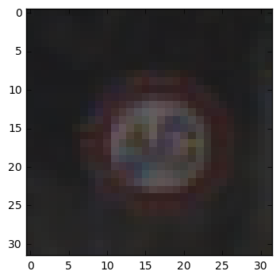

```
===Class 4====
```

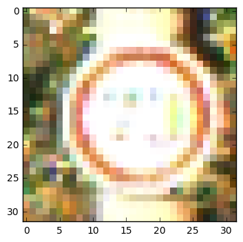

```
===Class 5====
```

[figure not shown]

```
===Class 6====
```

[figure not shown]

```
===Class 7====
```

[figure not shown]

```
===Class 8====
```

[figure not shown]

```
===Class 9====
```

[figure not shown]

```
===Class 10====
```

[figure not shown]

```
===Class 11====
```

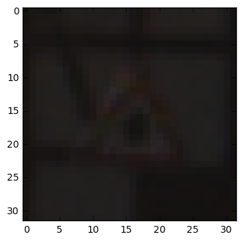

```
===Class 12====
```

[31 more figures not shown]

```python
##This block is just to display images,
number_images_to_show = 1



def get_n_index_of(list, item,n):
    temp_index = 0
    result = []
    for i in range(n):
        try:
            temp_index = list.index(item,temp_index+1)
            result.append(temp_index)
        except:
            break
    return result

image_samples = []
for class_num in range(n_classes):
    tmp_image_group = []
    tmp_indexes = get_n_index_of(list(y_train_all),class_num,number_images_to_show)
    for i in tmp_indexes:
        tmp_image_group.append(X_train_all[i])
        #tmp_image_group.append(i)
    image_samples.append([class_num,tmp_image_group])


for img_class in image_samples:
    print("===Class %d====\n"%img_class[0])
    for data in img_class[1]:
        plt.imshow(data, interpolation='nearest')
        plt.show()
```

## Step 2: Design and Test a Model Architecture

Design and implement a deep learning model that learns to recognize traffic signs. Train and test your model on the [German Traffic Sign Dataset](http://benchmark.ini.rub.de/?section=gtsrb&subsection=dataset).

There are various aspects to consider when thinking about this problem:

- Your model can be derived from a deep feedforward net or a deep convolutional network.
- Play around preprocessing techniques (normalization, rgb to grayscale, etc)
- Number of examples per label (some have more than others).
- Generate fake data.

Here is an example of a [published baseline model on this problem](http://yann.lecun.com/exdb/publis/pdf/sermanet-ijcnn-11.pdf). It's not required to be familiar with the approach used in the paper but, it's good practice to try to read papers like these.

### Implementation

Use the code cell (or multiple code cells, if necessary) to implement the first step of your project. Once you have completed your implementation and are satisfied with the results, be sure to thoroughly answer the questions that follow.

```python
### Preprocess the data here.
### Feel free to use as many code cells as needed.

#one hot encode the y
from sklearn.preprocessing import LabelBinarizer
encoder = LabelBinarizer()
encoder.fit(y_train_all)

if not one_hot_encoded:
    y_train_all = encoder.transform(y_train_all)
    y_test = encoder.transform(y_test)
    one_hot_encoded = True
```

```python
#normalize x
def normalize_image(image_data):
    """
    Normalize the image data with Min-Max scaling to a range of [0.1, 0.9]
    :param image_data: The image data to be normalized
    :return: Normalized image data
    """
    output = np.array(image_data, np.float32)
    a = 0.1
    b = 0.9
    greyscale_min = 0
    greyscale_max = 255
    output = a + ( ( (output - greyscale_min)*(b - a) )/( greyscale_max - greyscale_min ) )

    return output


if not normalized:
    X_train_all = normalize_image(X_train_all)
    X_test = normalize_image(X_test)
    normalized = True

print(X_train_all[0][0][:10])
print(y_train_all[0:3])
```

```
[[ 0.33529413  0.34470588  0.3509804 ]
 [ 0.33215687  0.33843136  0.34470588]
 [ 0.36039215  0.36352941  0.36039215]
 [ 0.41686276  0.38862744  0.36666667]
 [ 0.50784314  0.43568626  0.41999999]
 [ 0.58000004  0.45450979  0.45764709]
 [ 0.64274514  0.45764709  0.46705881]
 [ 0.68980396  0.48901963  0.48901963]
 [ 0.69607848  0.57372552  0.57058823]
 [ 0.86235303  0.81529421  0.82156867]]
[[1 0 0 0 0 0 0 0 0 0 0 0 0 0 0 0 0 0 0 0 0 0 0 0 0 0 0 0 0 0 0 0 0 0 0 0 0
  0 0 0 0 0 0]
 [1 0 0 0 0 0 0 0 0 0 0 0 0 0 0 0 0 0 0 0 0 0 0 0 0 0 0 0 0 0 0 0 0 0 0 0 0
  0 0 0 0 0 0]
 [1 0 0 0 0 0 0 0 0 0 0 0 0 0 0 0 0 0 0 0 0 0 0 0 0 0 0 0 0 0 0 0 0 0 0 0 0
  0 0 0 0 0 0]]
```

### Question 1

*Describe the techniques used to preprocess the data.*

**Answer:**

The Data is normalized with min-max range to be centered at 0.5 and within 0.1 - 0.9. Normalizing the data recudes computational error and also reduces the chances for the weights to grow. The min-max range normalization is chosen because of its simplicity.

```python
### Generate data additional (if you want to!)
### and split the data into training/validation/testing sets here.
### Feel free to use as many code cells as needed.

import tensorflow as tf
from sklearn.model_selection import train_test_split


X_train, X_valid, y_train, y_valid = train_test_split(X_train_all,y_train_all,
                                                          test_size=0.2,
                                                          random_state=10,
                                                          stratify=y_train_all)


n_train = X_train.shape[0]
n_test = X_test.shape[0]
n_valid = X_valid.shape[0] #not needed

print("Shape tarining set : ", X_train.shape, y_train.shape)
print("Shape validation set : ", X_valid.shape, y_valid.shape)
print("Shape testing set : ", X_test.shape, y_test.shape)

print("n_input:%d ; "%n_input,
     "n_test:%d ; "%n_test,
     "n_train:%d ; "%n_train,
     "n_valid:%d ; "%n_valid
     )
print("n_classes : ", n_classes)
```

```
Shape tarining set :  (31367, 32, 32, 3) (31367, 43)
Shape validation set :  (7842, 32, 32, 3) (7842, 43)
Shape testing set :  (12630, 32, 32, 3) (12630, 43)
n_input:3072 ;  n_test:12630 ;  n_train:31367 ;  n_valid:7842 ;
n_classes :  43
```

```python
#just attempting to visualize the profile of the training data
n_show_y = 40

data = np.argmax(y_train[0:n_show_y], axis=0)
print("train ", data)
#plt.plot(data)
#plt.show()

data = np.argmax(y_valid[0:n_show_y], axis=0)
print("valid ", data)
#plt.plot(data)
#plt.show()

#just attempting to visualize the profile of the test data
data = np.argmax(y_test[0:n_show_y], axis=0)
print("test ", data)
#plt.plot(data)
#plt.show()
```

```
train  [ 0  0 11 29 33  9  0 28  3  2 22  0 19 23  0  7  0 30  6  0  0  0  0  1 13
 27 10 24 14  0 15 16  0  0  0 12  0  0  0  0  0  0  0]
valid  [ 9 36 11 24  0  0 22 19 10  0  4  0 23  2  3  1 25  5 20  0  0  0  6  0  0
 16  0  0  0 21 17 13  0  7  0 32  0  0 28  0 15  0  0]
test  [ 0  1 34 23 14 30  0 11 39 15 27  4  7 26  0  0  0 31  6  0 17 16  0 12  0
  8  0 18  0  0  0  0  0  3 32  9  0  0  2  0  0  0  0]
```

### Question 2

*Describe how you set up the training, validation and testing data for your model. If you generated additional data, why?*

**Answer:**

Using train_test_split, 20% of training data is set as validation data

```python
### Define your architecture here.
### Feel free to use as many code cells as needed.

# Input/Image
x = tf.placeholder(tf.float32, [None, image_shape[0], image_shape[1], image_shape[2]])
y = tf.placeholder(tf.float32, [None, n_classes])

# Network Parameters
keep_prob = tf.placeholder(tf.float32)
```

```python
####################################
# Training Parameters
training_epochs = 200
batch_size = 128
dropout_rate = 0.50
learning_rate = 0.001
####################################
```

```python
# network structure parameters

down_sample_factor = 2
n_full_connected_layer = 1024
#n_full_connected_layer2 = 512

#Output depth
k_out = [32,64]
n_conv_layer = len(k_out)

#stride
stride = [[1,1,1,1],
          [1,1,1,1]]

#max pool down sampling
max_pool_k = [[1,down_sample_factor,down_sample_factor,1],
              [1,down_sample_factor,down_sample_factor,1]]

colour_channel = image_shape[2]

# Store layers weight & bias
k_fcl_in = image_shape[0]/(n_conv_layer*down_sample_factor) * image_shape[1]/(n_conv_layer*down_sample_factor) * k_out[-1]
k_fcl_in = int(k_fcl_in)

weights = {
    'c1': tf.Variable(tf.truncated_normal([5, 5, #filter size
                                        colour_channel,  #depth in
                                        k_out[0]],stddev=0.2)),  #depth out
    'c2': tf.Variable(tf.truncated_normal([5, 5, #filter size
                                        k_out[0],     #depth in
                                        k_out[1]],stddev=0.2)),  #depth out
    'fcl' : tf.Variable(tf.truncated_normal([k_fcl_in,
                                          n_full_connected_layer],stddev=0.2)),
    'fcl2' : tf.Variable(tf.truncated_normal([n_full_connected_layer,
                                          n_full_connected_layer2],stddev=0.2)),
    #'out': tf.Variable(tf.truncated_normal([n_full_connected_layer2, n_classes]))
    'out': tf.Variable(tf.truncated_normal([n_full_connected_layer, n_classes],stddev=0.2))
}
biases = {
    'c1': tf.Variable( tf.truncated_normal([k_out[0]],stddev=0.2) ),
    'c2': tf.Variable( tf.truncated_normal([k_out[1]],stddev=0.2) ),
    'fcl' :         tf.Variable( tf.truncated_normal([n_full_connected_layer],stddev=0.2) ),
    #'fcl2' :         tf.Variable( tf.truncated_normal([n_full_connected_layer2],stddev=0.2) ),
    'out':          tf.Variable( tf.truncated_normal([n_classes],stddev=0.2) )
}
```

```python
# Create some wrappers for simplicity
# from https://github.com/aymericdamien/TensorFlow-Examples/blob/master/notebooks/3_NeuralNetworks/convolutional_network.ipynb
def conv2d_maxpool2d(x, W, b, strides=[1,1,1,1], k_max_pool=[1,2,2,1]):
    # Conv2D wrapper, with bias and relu activation
    result = tf.nn.conv2d(x, W, strides=strides, padding='SAME')
    result = tf.nn.bias_add(result, b)
    result = tf.nn.relu(result)
    result = tf.nn.max_pool(result, ksize=k_max_pool, strides=k_max_pool,
                          padding='SAME')
    return result


# Create model
def conv_net(x, weights, biases, dropout, max_pool_k, stride):
    ## Reshape input picture
    #x = tf.reshape(x, shape=[-1, image_shape[0], image_shape[1], image_shape[2]])

    # Convolution Layer and Max Pooling (down-sampling)
    conv1 = conv2d_maxpool2d(x, weights['c1'], biases['c1'], stride[0], k_max_pool=max_pool_k[0])
    # Convolution Layer and Max Pooling (down-sampling)
    conv2 = conv2d_maxpool2d(conv1, weights['c2'], biases['c2'], stride[1], k_max_pool=max_pool_k[1])

    # Fully connected layer
    # Reshape conv2 output to fit fully connected layer input
    fc1 = tf.reshape(conv2, [-1, weights['fcl'].get_shape().as_list()[0]])
    fc1 = tf.add(tf.matmul(fc1, weights['fcl']), biases['fcl'])
    fc1 = tf.nn.relu(fc1)

    #fc12 = tf.reshape(fc1, [-1, weights['fcl2'].get_shape().as_list()[0]])
    #fc12 = tf.add(tf.matmul(fc12, weights['fcl2']), biases['fcl2'])
    #fc12 = tf.nn.relu(fc12)


    # Apply Dropout
    #fc12 = tf.nn.dropout(fc12, dropout)
    fc1 = tf.nn.dropout(fc1, dropout)

    # Output, class prediction
    #pred = tf.add(tf.matmul(fc12, weights['out']), biases['out'])
    pred = tf.add(tf.matmul(fc1, weights['out']), biases['out'])

    return pred
```

```python
# Construct model
pred = conv_net(x, weights, biases, keep_prob, max_pool_k, stride)

# Define loss and optimizer
softmax_logits = tf.nn.softmax_cross_entropy_with_logits(pred, y)
cost = tf.reduce_mean(softmax_logits)
optimizer = tf.train.AdamOptimizer(learning_rate=learning_rate).minimize(cost)
#optimizer = tf.train.GradientDescentOptimizer(learning_rate=learning_rate).minimize(cost)
```

```python
# Evaluate model

#making a correct_pred_wrapper() so that we can look inside for debugging purposes if needed
def correct_pred_wrapper(pred, y):
    pred_class = tf.argmax(pred, 1)
    y_class = tf.argmax(y, 1)
    correct_pred = tf.equal(pred_class, y_class)
    #printing something
    #tf.Print(pred_class, [pred_class], message="This is pred_class: ")
    #tf.Print(y_class, [y_class], message="This is y_class: ")

    #return tf.equal(pred_class, y_class),pred,pred_class,y_class
    elements_equal_to_value = tf.equal(correct_pred, True)
    as_ints = tf.cast(elements_equal_to_value, tf.int32)
    count = tf.reduce_sum(as_ints)
    tf.Print(count, [count], message="correct_pred count: ")
    return correct_pred

topFive=tf.nn.top_k(tf.nn.softmax(pred), k=5, sorted=True, name=None)
#y_class=tf.argmax(y, 1)
#correct_pred,ppred,pred_class,y_class = correct_pred_wrapper(pred, y)
correct_pred = correct_pred_wrapper(pred, y)
accuracy = tf.reduce_mean(tf.cast(correct_pred, tf.float32))
```

### Question 3

*What does your final architecture look like? (Type of model, layers, sizes, connectivity, etc.) For reference on how to build a deep neural network using TensorFlow, see Deep Neural Network in TensorFlow from the classroom.*

**Answer:**

The netowrk consists of 2 layers of convolution layer and 1 layer of fully connected layer that is then fed to the output layer. Basically,

Input: 32x32 pixels with 3 colour channel is fed to the network, Hidden Layer 1: Convolutional Layer Filter Size: 5x5 Depth: 32 max_pool: factor of 2 in both x and y axis of image Dropout: No Hidden Layer 2: Convolutional Layer Filter Size: 5x5 Depth: 64 max_pool: factor of 2 in both x and y axis of image Dropout: No Hidden Fully Connected Layer: Flat Fully Connected Layer 1024 nodes Dropout: 0.5 Output Layer: Flat Fully Connected Layer 43 nodes (43 possible classes)

```python
### Train your model here.
### Feel free to use as many code cells as needed.

import matplotlib.pyplot as plt


# Initializing the variables
init = tf.initialize_all_variables()

# The accuracy measured against the validation set
validation_accuracy = 0.0


print("training start")
# Launch the graph

with tf.Session() as sess:
    sess.run(init)
    # Training cycle
    for epoch in range(training_epochs):

        total_batch = int(n_train/batch_size)
        # Loop over all batches
        for batch_i in range(total_batch):
            batch_start = batch_i*batch_size
            batch_end = min((batch_start+batch_size),n_train)
            #if batch_i >= 300:
            #    print(batch_i, batch_start, batch_end)
            batch_x = X_train[batch_start:batch_end]
            batch_y = y_train[batch_start:batch_end]
            # Run optimization op (backprop) and cost op (to get loss value)

            sess.run(optimizer, feed_dict={x: batch_x, y: batch_y, keep_prob: dropout_rate})



        # Check accuracy against Validation data
        validation_accuracy,loss = sess.run([accuracy,cost], feed_dict={x: X_valid, y: y_valid, keep_prob: 1.})
        print("Epoch: %s, "%epoch, "Validataion Accuracy: %s, "%validation_accuracy, "Loss: %s"%loss)



    print("Optimization Finished !")
    saver = tf.train.Saver()
    saver.save(sess, 'my-model')
    print("===========================")
    print("Testing Accuracy:", \
    sess.run(accuracy, feed_dict={x: X_test,
                                      y: y_test,
                                      keep_prob: 1.}))
```

```
training start
Epoch: 0,  Validataion Accuracy: 0.493624,  Loss: 1.83546
Epoch: 1,  Validataion Accuracy: 0.731191,  Loss: 0.967272
Epoch: 2,  Validataion Accuracy: 0.855777,  Loss: 0.536201
Epoch: 3,  Validataion Accuracy: 0.911247,  Loss: 0.336151
Epoch: 4,  Validataion Accuracy: 0.942489,  Loss: 0.227269
Epoch: 5,  Validataion Accuracy: 0.949758,  Loss: 0.180132
Epoch: 6,  Validataion Accuracy: 0.96659,  Loss: 0.125288
Epoch: 7,  Validataion Accuracy: 0.970288,  Loss: 0.112255
Epoch: 8,  Validataion Accuracy: 0.98049,  Loss: 0.0813111
Epoch: 9,  Validataion Accuracy: 0.980235,  Loss: 0.0719736
Epoch: 10,  Validataion Accuracy: 0.982785,  Loss: 0.068913
Epoch: 11,  Validataion Accuracy: 0.987631,  Loss: 0.0575883
Epoch: 12,  Validataion Accuracy: 0.986611,  Loss: 0.0531118
Epoch: 13,  Validataion Accuracy: 0.988651,  Loss: 0.0491684
Epoch: 14,  Validataion Accuracy: 0.988141,  Loss: 0.0499535
Epoch: 15,  Validataion Accuracy: 0.989671,  Loss: 0.0441561
Epoch: 16,  Validataion Accuracy: 0.990436,  Loss: 0.0395552
Epoch: 17,  Validataion Accuracy: 0.991074,  Loss: 0.0399652
Epoch: 18,  Validataion Accuracy: 0.991839,  Loss: 0.0379322
Epoch: 19,  Validataion Accuracy: 0.990946,  Loss: 0.0377204
Epoch: 20,  Validataion Accuracy: 0.991711,  Loss: 0.038296
Epoch: 21,  Validataion Accuracy: 0.991456,  Loss: 0.037247
Epoch: 22,  Validataion Accuracy: 0.993752,  Loss: 0.0326584
Epoch: 23,  Validataion Accuracy: 0.992221,  Loss: 0.0402543
Epoch: 24,  Validataion Accuracy: 0.993624,  Loss: 0.0323002
Epoch: 25,  Validataion Accuracy: 0.993752,  Loss: 0.0375448
Epoch: 26,  Validataion Accuracy: 0.992859,  Loss: 0.0337273
Epoch: 27,  Validataion Accuracy: 0.994007,  Loss: 0.0315431
Epoch: 28,  Validataion Accuracy: 0.994007,  Loss: 0.0429365
Epoch: 29,  Validataion Accuracy: 0.993497,  Loss: 0.0405834
Epoch: 30,  Validataion Accuracy: 0.993879,  Loss: 0.0380683
Epoch: 31,  Validataion Accuracy: 0.994517,  Loss: 0.0423437
Epoch: 32,  Validataion Accuracy: 0.992476,  Loss: 0.0340474
Epoch: 33,  Validataion Accuracy: 0.994007,  Loss: 0.0380042
Epoch: 34,  Validataion Accuracy: 0.993752,  Loss: 0.0386365
Epoch: 35,  Validataion Accuracy: 0.993879,  Loss: 0.0400821
Epoch: 36,  Validataion Accuracy: 0.993752,  Loss: 0.0332866
Epoch: 37,  Validataion Accuracy: 0.994517,  Loss: 0.0375344
Epoch: 38,  Validataion Accuracy: 0.994389,  Loss: 0.0328
```

[output cut: 149 more lines]

```
Epoch: 188,  Validataion Accuracy: 0.995282,  Loss: 0.0945918
Epoch: 189,  Validataion Accuracy: 0.996047,  Loss: 0.0686747
Epoch: 190,  Validataion Accuracy: 0.995027,  Loss: 0.0782239
Epoch: 191,  Validataion Accuracy: 0.99643,  Loss: 0.0951447
Epoch: 192,  Validataion Accuracy: 0.997067,  Loss: 0.0572378
Epoch: 193,  Validataion Accuracy: 0.99643,  Loss: 0.0764889
Epoch: 194,  Validataion Accuracy: 0.996812,  Loss: 0.0651426
Epoch: 195,  Validataion Accuracy: 0.996174,  Loss: 0.0703144
Epoch: 196,  Validataion Accuracy: 0.99694,  Loss: 0.0569102
Epoch: 197,  Validataion Accuracy: 0.995919,  Loss: 0.082263
Epoch: 198,  Validataion Accuracy: 0.995919,  Loss: 0.0741547
Epoch: 199,  Validataion Accuracy: 0.996812,  Loss: 0.0729755
Optimization Finished !
===========================
Testing Accuracy: 0.946556
```

### Question 4

*How did you train your model? (Type of optimizer, batch size, epochs, hyperparameters, etc.)*

**Answer:** I am using AdamOptimizer. And the parameters are as follows,

training_epochs = 200 batch_size = 128 dropout_rate = 0.50 learning_rate = 0.001

**Answer Extended:**

Somewhere between 15 and 20 training epocs was consistently yielding better than 90% test accuracy already. Hence I decided to multiply that by 10 and do a overnight training with epoc of 200.

I have tried both AdamOptimizer and GradientDescent, however over 10 epocs, AdamOptimizer seems to have performed better, hence I chose to use AdamOptimizer.

Drop out rate of 0.5 and 0.75 didn't seem to make a difference most of the time, so I used 0.5 to aggressively evade overfitting.

I actually started with batch_size of 128 and never tried to change it.

Learning rate of 0.0001 seems to converge slower, 0.01 isn't always that smooth but usually does pretty well also.

Hidden Convolution with layers with k=16,32 doesn't seem to do as well within 10 epocs, where as k=64,128 is just too slow.

I have also tried quite a few other combinations of the training variables, different convolution layer depths and different number/size of fully connected layer. But during most of my trials, I unfortunately was using random normal instead of truncated normal to initialize my training weights. Hence didn't really yield any useful result and insights.

**Answer Extended 2:**

Overall, I started right away by building a deep Convolutional Network similar to that in class.

However my validation accuracy is not going down with loss. Hence I went through the following process before I get my first working model

1. Restructed my code using idea from AymericDamien's github example.
2. Further resturcture my code to make compute most constants from some initially defined constant as much as possible. This way I would be able to test different sturctures easier. For example, calculating k_fcl_in from other variables
3. Tried a bunch of different setups. Tried to setup GPU on Mac, VM, AWS with no success.
4. Vivek point out that truncatedNormal should be used
5. Decided to stick to current network structure and train the network with epoc = 200

### Question 5

*What approach did you take in coming up with a solution to this problem?*

**Answer:**

I set up basic convolution neural network to solve this problem.

## Step 3: Test a Model on New Images

Take several pictures of traffic signs that you find on the web or around you (at least five), and run them through your classifier on your computer to produce example results. The classifier might not recognize some local signs but it could prove interesting nonetheless.

You may find `signnames.csv` useful as it contains mappings from the class id (integer) to the actual sign name.

### Implementation

Use the code cell (or multiple code cells, if necessary) to implement the first step of your project. Once you have completed your implementation and are satisfied with the results, be sure to thoroughly answer the questions that follow.

```
13_yield.jpg
14_stopSign.jpg
17_noEntry.jpg
1_speedLimit_30.jpg
25_roadWork.jpg
28_childrenCrossing.jpg
38_keepRight.jpg
99_BikePathEnds.jpg
===========
```

[figure not shown]

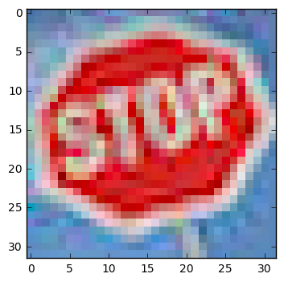

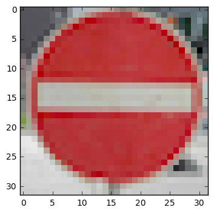

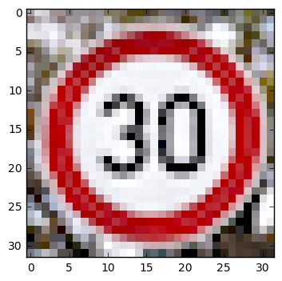

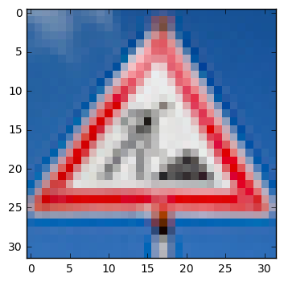

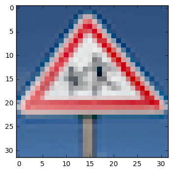

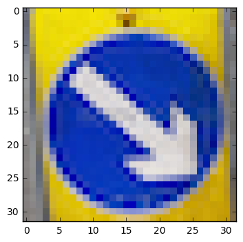

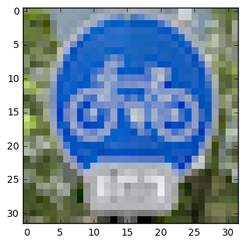

```python
### Load the images and plot them here.
### Feel free to use as many code cells as needed.
import matplotlib.image as mpimg
import numpy as np
import cv2
import os
from matplotlib import pyplot as plt
import tensorflow as tf

path_test_images = "Extra/"
X_extra = []
y_extra = []
for name_image in os.listdir(path_test_images):
    if name_image.endswith('jpg'):
        print(name_image)
        y_extra.append(int(name_image.split("_")[0]))
        image = mpimg.imread(os.path.join(path_test_images, name_image))
        X_extra.append(image)
print("===========")
for data in X_extra:
    plt.imshow(data, interpolation='nearest')
    plt.show()

X_extra_normalized = normalize_image(X_extra)
```

### Question 6

*Choose five candidate images of traffic signs and provide them in the report. Are there any particular qualities of the image(s) that might make classification difficult? It would be helpful to plot the images in the notebook.*

```python
### Run the predictions here.
### Feel free to use as many code cells as needed.


sess_extra = tf.Session()
init = tf.initialize_all_variables()
sess_extra.run(init)
new_saver = tf.train.import_meta_graph('my-model.meta')
new_saver.restore(sess_extra, tf.train.latest_checkpoint('./'))


print(X_extra_normalized.shape)
pred,topFive = sess_extra.run([pred,topFive], feed_dict={x: X_extra_normalized, keep_prob: 1.0})
```

```
(8, 32, 32, 3)
```

```python
pred_class_extra = np.argmax(pred,axis=1)
print("prediction is :",pred_class_extra)
print("real class is :",y_extra)

print("where class 99 in y_extra symbolizes a class that is not seen in our training data")
```

```
prediction is : [13 14 17  1 25 30 38 34]
real class is : [13, 14, 17, 1, 25, 28, 38, 99]
where class 99 in y_extra symbolizes a class that is not seen in our training data
```

### Question 7

*Is your model able to perform equally well on captured pictures or a live camera stream when compared to testing on the dataset?*

**Answer:** See above code block. I tested 8 images

It got 6 out of 7 correct, and the 8th image is not one that is in training set, Hence I would say the model performs alright but not as well as in the training/validation/testing set. However, we should also keep in mind that 7 images is not a large enough set to be statistcally meaningful.

At 32x32 pixels, "Beware of ice/snow" and "Children crossing" sign do look somewhat similar even to human eyes, but I wasn't really expecting that the image that I have chosen to actually be difficult to classify. This was sort of a suprise to me.

```python
### Visualize the softmax probabilities here.
### Feel free to use as many code cells as needed.

print(topFive)
```

```
TopKV2(values=array([[  1.00000000e+00,   0.00000000e+00,   0.00000000e+00,
          0.00000000e+00,   0.00000000e+00],
       [  1.00000000e+00,   0.00000000e+00,   0.00000000e+00,
          0.00000000e+00,   0.00000000e+00],
       [  1.00000000e+00,   0.00000000e+00,   0.00000000e+00,
          0.00000000e+00,   0.00000000e+00],
       [  1.00000000e+00,   0.00000000e+00,   0.00000000e+00,
          0.00000000e+00,   0.00000000e+00],
       [  1.00000000e+00,   0.00000000e+00,   0.00000000e+00,
          0.00000000e+00,   0.00000000e+00],
       [  9.99423027e-01,   5.76826569e-04,   1.42029762e-07,
          2.88271220e-08,   2.56295388e-16],
       [  1.00000000e+00,   0.00000000e+00,   0.00000000e+00,
          0.00000000e+00,   0.00000000e+00],
       [  1.00000000e+00,   5.50151497e-25,   0.00000000e+00,
          0.00000000e+00,   0.00000000e+00]], dtype=float32), indices=array([[13,  0,  1,  2,  3],
       [14,  0,  1,  2,  3],
       [17,  0,  1,  2,  3],
       [ 1,  0,  2,  3,  4],
       [25,  0,  1,  2,  3],
       [30, 25, 18,  5, 20],
       [38,  0,  1,  2,  3],
       [34, 33,  0,  1,  2]], dtype=int32))
```

### Question 8

*Use the model's softmax probabilities to visualize the **certainty** of its predictions, [`tf.nn.top_k`](https://www.tensorflow.org/versions/r0.11/api_docs/python/nn.html#top_k) could prove helpful here. Which predictions is the model certain of? Uncertain? If the model was incorrect in its initial prediction, does the correct prediction appear in the top k? (k should be 5 at most)*

**Answer:**

Image 6: the correct class is not one of top s5.

Everything but image 6 have ~100% confidence on its top prediction.

The top prediction of image 6 (incorrect prediction) is the lowest among the 8 images, though it is still quite high at 99.94% confidence.

But interestingly enough image 8 also have a very high confidence for its top prediction.

### Question 9

*If necessary, provide documentation for how an interface was built for your model to load and classify newly-acquired images.*

**Answer:**

the model is saved using saver = tf.train.Saver() saver.save(sess, 'my-model')

Hence, can be loaded by tf.train.import_meta_graph('my-model.meta')